# Class Agenda

1. Python Variables - String, Number, List, Dictionaries
2. Basic Data Wrangling (if condition, while, for statements) and Functions/Classes
3. Numpy and Pandas - Arrays, Series, DataFrame
4. Reading and Writing files (text, csv, json, SAS ) from the local drives
5. Adavanced Data Analysis - merging, transposing, statistical analysis (t-test, fisher exact, survival)
6. Data Visulalization - matplotlib
7. Machine Learning using Python - image data analysis using Logistic Regression, SVM, Deep Learning and Convolutional Neural Network
8. SDTM DM datasets development

# Python Variables

The type of the most popular variables is

- String
- Number
- List
- Tuples
- Sets
- Dictionary

## Variables

- Variable names can contain letters, numbers and an underscore. Ex. var, var1, var_1
- Variable names can start with letters and an underscore, but not with numbers. Ex, _var
- Variable names can not be same as Python functions or keywords. Ex. print
- Variable with upper case is different from that with lower case Ex. var, Var
- New variables can overwrite previously-defined variables

The architecture of variables is

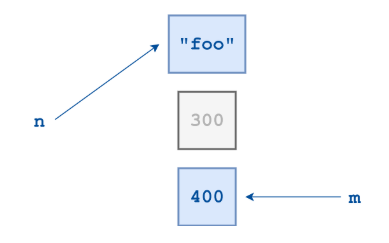

```python
var = 1
var1 = 2
var_1 = 3
_var = 4
```

```python
print(var)
print(var1)
print(var_1)
print(_var)
```

```
1
2
3
4
```

```python
# Upper case - different variables
Var = 5
print(Var)
```

```
5
```

```python
# overwriting the previous defined variables
var = 6
print(var)
var = 'Hi'
print(var)
```

```
6
Hi
```

```python
# Create variable starting with number
1var = 6
```

```
  File "<ipython-input-5-62e5f6ef5f05>", line 2
    1var = 6
     ^
SyntaxError: invalid syntax
```

## String

How to create String - use the double quoation ("") or single ('')

```python
message = "Hello"
message2 = 'Hi'
```

```python
print(message)
print(message2)
```

```
Hello
Hi
```

```python
print(type(message))
print(type(message2))
```

```
<class 'str'>
<class 'str'>
```

```python
## Concantenation of string variables
message3 = "Kevin"
message4 = message + ', ' + message2 + message3
message4
```

```
'Hello, HiKevin'
```

```python
print(type(message4))
```

```
<class 'str'>
```

```python
message3 = message*2
print(message3)
print(type(message3))
```

```
HelloHello
<class 'str'>
```

#### String method

```python
### method that we can use for message string class(ojbect)
dir(message)
```

```
['__add__',
 '__class__',
 '__contains__',
 '__delattr__',
 '__dir__',
 '__doc__',
 '__eq__',
 '__format__',
 '__ge__',
 '__getattribute__',
 '__getitem__',
 '__getnewargs__',
 '__gt__',
 '__hash__',
 '__init__',
 '__init_subclass__',
 '__iter__',
 '__le__',
 '__len__',
 '__lt__',
 '__mod__',
 '__mul__',
 '__ne__',
 '__new__',
 '__reduce__',
 '__reduce_ex__',
 '__repr__',
 '__rmod__',
 '__rmul__',
 '__setattr__',
 '__sizeof__',
 '__str__',
 '__subclasshook__',
 'capitalize',
 'casefold',
 'center',
 'count',
 'encode',
 'endswith',
 'expandtabs',
```

[output cut: 23 more lines]

```
 'rfind',
 'rindex',
 'rjust',
 'rpartition',
 'rsplit',
 'rstrip',
 'split',
 'splitlines',
 'startswith',
 'strip',
 'swapcase',
 'title',
 'translate',
 'upper',
 'zfill']
```

```python
print(message.upper())
print(message.lower())
```

```
HELLO
hello
```

### Number

type:

- integer - int
- floating number - float

```python
## integer
num1 = 1
```

```python
print(type(num1))
print(num1)
```

```
<class 'int'>
1
```

```python
num2 = 2
num3 = num1*num2
print(type(num3))
print(num3)
```

```
<class 'int'>
2
```

```python
## floating number
num4 = 1.2
print(type(num4))
```

```
<class 'float'>
```

```python
## Add floating number and integer
num5 = num4 + num3
print(num5)
print(type(num5))
```

```
3.2
<class 'float'>
```

```python
## Converting integer to floating
num6 = num1 * 1.0
print(num6)
print(type(num6))

## use function of float
num7 = float(num1)
print(num7)
print(type(num7))
```

```
1.0
<class 'float'>
1.0
<class 'float'>
```

```python
## Converting floating to integer
num8 = int(num7)
print(num8)
print(type(num8))

num9 = 1.6
num10 = int(num9)
print(num10)
num11 = int(round(num9))
print(num11)
```

```
1
<class 'int'>
1
2
```

```python
## Convert number to string
str1 = str(num1)
print(str1)
print(type(str1))

str2 = str1*2  #different from interger multilication
print(str2)
```

```
1
<class 'str'>
11
```

```python
# string and number can't be added
mixed = message + num1
```

```
---------------------------------------------------------------------------
TypeError                                 Traceback (most recent call last)
<ipython-input-22-3fbf8b73c825> in <module>
      1 # string and number can't be added
----> 2 mixed = message + num1

TypeError: can only concatenate str (not "int") to str
```

## List

A list is a collection of items in a particular order which is movable, changeable, and defined by havaing value between sqaure brackets. Each element or favlue that is inside of a list is called an item.  
A list is <class, 'list'>

Examples is list_example = [1,2,3,4,5]

```python
## List example
CT_AESEV = ['mild', 'moderate', 'severe']
print(CT_AESEV)
print(type(CT_AESEV))

CT_AESEVCD = [0,1,2]
print(CT_AESEVCD)
print(type(CT_AESEVCD))
```

```
['mild', 'moderate', 'severe']
<class 'list'>
[0, 1, 2]
<class 'list'>
```

List consists of index and value. Each value has its index (location) from List. Index is compatiable to *N* in SAS.

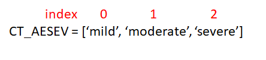

```python
## Each item in list
## index starts from 0 not from 1
print(CT_AESEV[1])
CT_AESEV1 = CT_AESEV[1] # string
print(type(CT_AESEV1))

print(CT_AESEVCD[1])
CT_AESEVCD1 = CT_AESEVCD[1] # integer
print(type(CT_AESEVCD1))
```

```
moderate
<class 'str'>
1
<class 'int'>
```

```python
CT_AESEV_T = ['MODERATE', 1]
print(CT_AESEV_T)
print(type(CT_AESEV_T[0]))
print(type(CT_AESEV_T[1]))
```

```
['MODERATE', 1]
<class 'str'>
<class 'int'>
```

```python
## Changing items in the list
CT_AESEV[1] = 'normal'
print(CT_AESEV)
```

```
['mild', 'normal', 'severe']
```

```python
## Adding itemas in the list
CT_AESEV.append('not applicable')
print(CT_AESEV)
```

```
['mild', 'normal', 'severe', 'not applicable']
```

```python
## inserting item in certain order
CT_AESEV.insert(1,'moderate')  # insert with 1 will insert 'moderate' in index order of 1
print(CT_AESEV)
```

```
['mild', 'moderate', 'normal', 'severe', 'not applicable']
```

```python
## removing iteam from list
del CT_AESEV[2] # remove item using index
print(CT_AESEV)

CT_AESEV.remove('not applicable') # remove item using values
print(CT_AESEV)
print(type(CT_AESEV))
```

```
['mild', 'moderate', 'severe', 'not applicable']
['mild', 'moderate', 'severe']
<class 'list'>
```

```python
## Finding the length of list
print(CT_AESEV)
len(CT_AESEV)
```

```
['mild', 'moderate', 'severe']
```

```
3
```

```python
## using FOR loops with list
for i in CT_AESEV:
    print(i)
```

```
mild
moderate
severe
```

```python
## Creating a list
a = 1 ; b = 2; c = 3; d = 4
list_num = []
print(type(list_num))

list_num.append(a)
print(list_num)
list_num.append(b)
print(list_num)
```

```
<class 'list'>
[1]
[1, 2]
```

```python
## Subsetting a list
list_num2 = [0,1,2,3,4,5,6,7,8,10]
print(list_num2)

list_num_sub2 = list_num2[:2] # subsetting 0 to 1 index number
print(list_num_sub2)

list_num_sub4 = list_num2[:4] # subsetting 0 to 3 index number
print(list_num_sub4)

list_num_sub3_5 = list_num2[3:5] # subsetting 3 to 4 index number
print(list_num_sub3_5)

list_num_sub4_last = list_num2[4:] # subsetting from 4 to last index number
print(list_num_sub4_last)

list_num_sub_4minus = list_num2[-4:] # subsetting from -4 (from the right) to last index number
print(list_num_sub_4minus)
print(type(list_num_sub_4minus))
print(type(list_num_sub_4minus[1]))
```

```
[0, 1, 2, 3, 4, 5, 6, 7, 8, 10]
[0, 1]
[0, 1, 2, 3]
[3, 4]
[4, 5, 6, 7, 8, 10]
[6, 7, 8, 10]
<class 'list'>
<class 'int'>
```

```python
## List can include duplicates
list_num.append(2)
list_num
```

```
[1, 2, 2]
```

## Tuples

A tuple is an immuntable list which can't be modified  
It is a class of 'tuple'

```python
## develop tuple class
tuple1 = (0,1,2,3)
print(tuple1)
print(type(tuple1))
```

```
(0, 1, 2, 3)
<class 'tuple'>
```

```python
print(tuple1[0])
tuple1[0] = 10  ## error message
```

```
0
```

```
---------------------------------------------------------------------------
TypeError                                 Traceback (most recent call last)
<ipython-input-36-2f6cd7963626> in <module>
      1 print(tuple1[0])
----> 2 tuple1[0] = 10  ## error message

TypeError: 'tuple' object does not support item assignment
```

```python
## Adding new elements to tuples
tuple1.append(4) ## can't append new element to TUPLES
```

```
---------------------------------------------------------------------------
AttributeError                            Traceback (most recent call last)
<ipython-input-37-827841a7f69e> in <module>
      1 ## Adding new elements to tuples
----> 2 tuple1.append(4) ## can't append new element to TUPLES

AttributeError: 'tuple' object has no attribute 'append'
```

```python
## adding new tuple to the previous tuple
tuple2 = tuple1 + (3,) ## can include duplicates
tuple2
```

```
(0, 1, 2, 3, 3)
```

```python
## subsets of tuples
tuple3 = tuple1[:2]
tuple3
```

```
(0, 1)
```

```python
## using FOR loops to print each item of TUPLES
for tup in tuple1:
    print(tup)
```

```
0
1
2
3
```

## Sets

A set is an unordered collection with no duplicate elements. It does not have an index.

```python
## create set class
sets1 = {'white','black','asian','other'}
print(sets1)
print(type(sets1))
```

```
{'asian', 'black', 'white', 'other'}
<class 'set'>
```

```python
print(sets1[0])  ## error  - no index in SETS
```

```
---------------------------------------------------------------------------
TypeError                                 Traceback (most recent call last)
<ipython-input-42-b0af457a1839> in <module>
----> 1 print(sets1[0])  ## error  - no index in SETS

TypeError: 'set' object is not subscriptable
```

```python
## use loops to print each element of SETS
for set1 in sets1:
    print(set1)
```

```
asian
black
white
other
```

```python
## Subsetting of SETS - ## error message
sets2 = sets1[:2]
```

```
---------------------------------------------------------------------------
TypeError                                 Traceback (most recent call last)
<ipython-input-44-d7fd083dde3d> in <module>
      1 ## Subsetting of SETS
----> 2 sets2 = sets1[:2]

TypeError: 'set' object is not subscriptable
```

```python
## adding new element to SETS
sets1.add('hispanic')
sets1
```

```
{'asian', 'black', 'hispanic', 'other', 'white'}
```

```python
## adding new duplicate element to SETS
sets1.add('hispanic') # no duplicates added
sets1
```

```
{'asian', 'black', 'hispanic', 'other', 'white'}
```

```python
## develope set class.  It creates no duplicate
sets2 = set('abracadabra')
print(sets2)

sets3 = set('12567345')
print(sets3)
```

```
{'b', 'a', 'r', 'c', 'd'}
{'3', '5', '7', '4', '1', '2', '6'}
```

### Key difference of List, Tuples and Sets

List - Mutable, index, duplicate  
Tuples - immutable, index, duplicate  
Sets - mutable, no index, no duplicate

## Dictionary

A dictionary is a unordered collection which is changeable and indexed.  
Characteristics of Dictionary

- mutable
- dynamic. It can grow and shrink.
- nested. It can contain other data structures such as list, set, tuple and dictionary.
- Dictionary elements are accessed by keys while as list by index.

Its main structure is {'key': value, 'key': value}.  
The example is {'sex' : 'male', 'race' : 'white', 'age': 34}

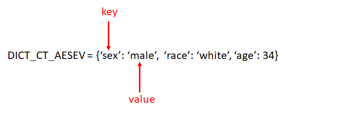

```python
## create dictionary
subject1 = {'sex':'male', 'race':'white', 'age':34}
print(subject1)
print(type(subject1))
```

```
{'sex': 'male', 'race': 'white', 'age': 34}
<class 'dict'>
```

A dictionary is data collections of key-value pairs. key could be number, string, list or dictionary.

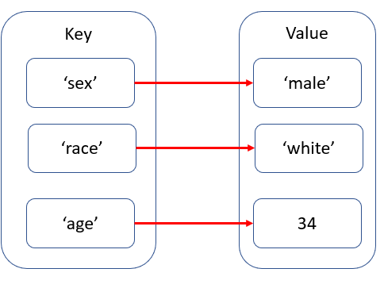

In typical SAS datasets,

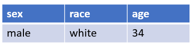

```python
## use key in dictionary
print(subject1['sex'])
## modifying dictionary
subject1['sex']= 'female'  # update the value of key 'sex'
print(subject1)
```

```
male
{'sex': 'female', 'race': 'white', 'age': 34}
```

```python
## Value of different key
val1 = subject1['sex']
print(val1)
print(type(val1))
val2 = subject1['age']
print(val2)
print(type(val2))
```

```
female
<class 'str'>
34
<class 'int'>
```

```python
### Remove key-value pairs
subject2 = {'subjid': '001-001', 'sex':'male', 'race':'white', 'age':34}
print(subject2)
print(len(subject2))
del subject2['subjid']  # remove subjid key
print(subject2)
print(len(subject2))
```

```
{'subjid': '001-001', 'sex': 'male', 'race': 'white', 'age': 34}
4
{'sex': 'male', 'race': 'white', 'age': 34}
3
```

```python
## For looping dictionary
subject3 = {'subjid': '001-002', 'sex':'female', 'race':'asian'}
for key, value in subject3.items(): ## for loop on each item
    print("Key: " + key)
    print("Value: " + value)
```

```
Key: subjid
Value: 001-002
Key: sex
Value: female
Key: race
Value: asian
```

```python
## For looping dictionary
for n in subject3.values():
    print("Value: " + n)
```

```
Value: 001-002
Value: female
Value: asian
```

Nesting in Dictionary

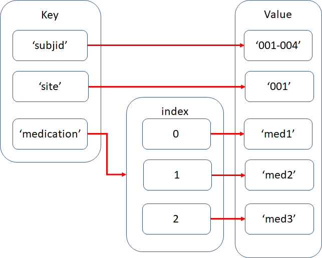

In SAS datasets,

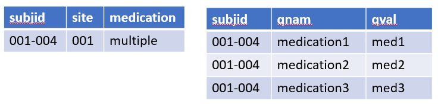

```python
## Nesting in Dictionary - List in a dictionary
subject4 = {'subjid': '001-004', 'site':'001', 'medication':['med1','med2','med3']}
print(subject4)

## print a list of keys
print(subject4.keys())

## subset using key medication
med_subj4 = subject4['medication']
print(med_subj4)
print(type(med_subj4))
```

```
{'subjid': '001-004', 'site': '001', 'medication': ['med1', 'med2', 'med3']}
dict_keys(['subjid', 'site', 'medication'])
['med1', 'med2', 'med3']
<class 'list'>
```

```python
## subset using index
site_subj4 = subject4[1]  ## no index in dictionary - Error message
```

```
---------------------------------------------------------------------------
KeyError                                  Traceback (most recent call last)
<ipython-input-55-c94e61ee2ca9> in <module>
      1 ## subset using index
----> 2 site_subj4 = subject4[1]  ## no index in dictionary - Error message

KeyError: 1
```

```python
## Nesting in Dictionary - dictionary in a dictionary
subject5 = {'subjid': '001-005', 'site':'001', 'name':{'last': 'Smith', 'first': 'Johh'}}
print(subject5)

## subset dictionary
name_sub5 = subject5['name']
print(name_sub5)
print(type(name_sub5))

## subject-subset of dictionary
firstname_sub5 = subject5['name']['first']
print(firstname_sub5)
print(type(firstname_sub5))
```

```
{'subjid': '001-005', 'site': '001', 'name': {'last': 'Smith', 'first': 'Johh'}}
{'last': 'Smith', 'first': 'Johh'}
<class 'dict'>
Johh
<class 'str'>
```

## Date Variable

```python
## import date class
import time
from datetime import date
```

```python
## create date variable using date class
today = date.today()
print("Today is : ", today)
print("Type of date from date class : ", type(today))
today_year = today.year
print("Year of today using year method of date class : ", today_year)
print("Type of variable : ", type(today_year))
```

```
Today is :  2021-05-29
Type of date from date class :  <class 'datetime.date'>
Year of today using year method of date class :  2021
Type of variable :  <class 'int'>
```

```python
print(today.strftime("%A %d. %B %Y"))
print(today.strftime("%d/%m/%y"))
print(today.strftime("%d/%m/%Y"))
print(today.strftime("%d. %B %Y"))
```

```
Saturday 29. May 2021
29/05/21
29/05/2021
29. May 2021
```

```python
## Create date class object
my_brthdt = date(2018, 11, 12)
print(my_brthdt)
print(type(my_brthdt))
```

```
2018-11-12
<class 'datetime.date'>
```

```python
date1 = date(2017,1,1)
date2 = date(2017,1,3)
date3 = date(2017,1,10)
```

```python
## date comparison
if date2 > date1:
    print(date2, " is later than ", date1)
```

```
2017-01-03  is later than  2017-01-01
```

```python
### create difference between dates
diff_date = date3 - date1
print("Difference between dates is ", diff_date)
print("Type of variable is ", type(diff_date))
```

```
Difference between dates is  9 days, 0:00:00
Type of variable is  <class 'datetime.timedelta'>
```